# BGC Details

Published

July 8, 2025

This page shows metadata about a selected predicted biosynthetic region: context, genes, functional domains, detector support and downloads.

## Overview section

At the top of the BGC details page, users will find summary information and related datasets about the *aggregated region*. This includes:

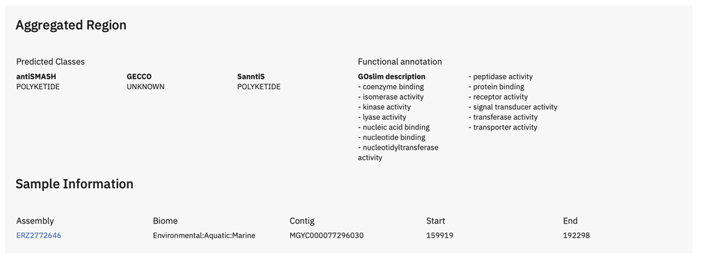

### Sample information

- **Assembly accession**: The ENA (European Nucleotide Archive) assembly accession associated with the predicted BGC region. This is a unique identifier for the assembly from which the BGC was predicted. The assembly accession is linked to the MGnify assembly page, where users can explore the assembly in more detail.
- **Biome**: Information about the biome from which the assembly originates. Biome data provides context on the environmental source of the DNA sequence, which can be important for understanding the ecological relevance of the BGC.
- **Contig information**: This includes contig accession (MGYC) where the BGC was predicted, as well as the start and end positions of the *aggregated region*.
- **Predicted classes**: Each detector’s class call—agreement increases confidence.
- **Functional annotation**: Slimmed GO functional hints for enzymes in the region; scan for tailoring/modification clues.

## Explore region

### Region plot

The plot is a compact interactive map of the region:

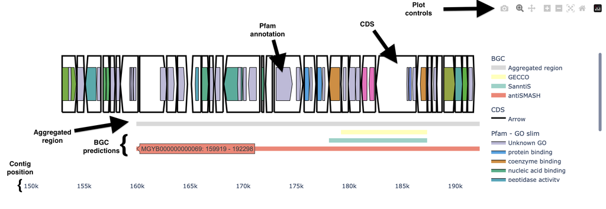

– **CDS (genes)**: White arrows (direction = strand). Click to see protein sequence & domains. – **Pfam domains**: Coloured mini‑arrows inside genes; colour reflects general functional category. – **Tool predictions**: Coloured horizontal bars—compare extent and overlap.

Hovering the cursor over the elements will display accession and other information.

### Protein information

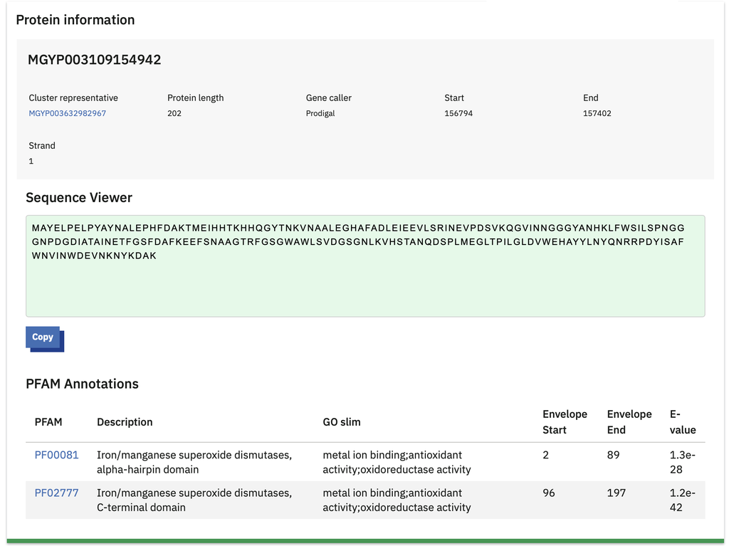

Clicking a gene reveals:

- **Protein sequence**: Copy for alignment or motif checks.
- **Pfam details**: InterPro‑linked descriptions—use to infer enzymatic steps.
- **Representative protein**: Link to MGnify protein cluster representative for broader context.

## Download options

The BGC details page offers download options for users who wish to retrieve data for further analysis:

- **GeneBank**: This file contains the nucleotide sequence of the aggregated BGC region, along with annotated features such as predicted genes, translation sequences, Pfam domains, and BGC region information. The GeneBank format is widely used for storing detailed sequence data, and it is compatible with various bioinformatics tools.
- **JSON**: The JSON file is formatted according to antiSMASH specifications and can be used directly within the antiSMASH ecosystem. This file is useful for users who want to perform further analysis using antiSMASH tools or integrate the data into their existing antiSMASH workflows.
- **FASTA**: This file provides the nucleotide sequence of the aggregated BGC region in FASTA format. FASTA is a simple, widely-used format for representing nucleotide sequences, making it easy to use with various sequence analysis tools.

Choose the format that fits your next step—GenBank for genome browsers, JSON (antiSMASH‑style) for re‑analysis, FASTA for sequence Alignments.

## Quick interpretation tips

- Consistent class across detectors = stronger lead.
- Many tailoring/modification domains (e.g. glycosyltransferase, methyltransferase) can point to structural novelty.
- “Double” completeness in search results usually means partial edges—treat with caution for cloning or heterologous expression planning.
- Compare span differences between tools: wide disagreement may indicate fragmented assembly or borderline confidence.